# Full House Analysis

Ekansh Arora

2025-09-19

# Exploring Era Adjustments in Baseball

## Introduction

I’m exploring the fullhouse package to understand how era adjustments work. My research question is pretty simple: do era adjustments change how we see different decades in baseball?

## Setup

```r
library(fullhouse)
library(tidyverse)

# Load the batting data
data(batters_adjusted)
```

## Looking at the Data

```r
# See what's in the dataset
head(batters_adjusted)
```

```
## # A tibble: 6 × 15
##   name      playerID   age  year    PA    AB     H    HR    BB    BA   OBP   HBP
##   <chr>     <chr>    <int> <int> <int> <int> <int> <dbl> <int> <dbl> <dbl> <int>
## 1 David Aa… aardsda…    22  2004     5     4     1     0     1 0.25  0.4       0
## 2 David Aa… aardsda…    24  2006    26    23     7     1     3 0.304 0.385     0
## 3 David Aa… aardsda…    25  2007     1     0     0     0     1 0     1         0
## 4 David Aa… aardsda…    26  2008    12    10     3     0     2 0.3   0.417     0
## 5 David Aa… aardsda…    27  2009     2     1     0     0     1 0     0.5       0
## 6 David Aa… aardsda…    28  2010     3     2     1     0     1 0.5   0.667     0
## # ℹ 3 more variables: SF <int>, ebWAR <dbl>, efWAR <dbl>
```

```r
# Check the years covered
range(batters_adjusted$year)
```

```
## [1] 1871 2024
```

The data has ebWAR and efWAR columns. From what I understand, ebWAR is era-based and efWAR is era-free, so the difference should show the era adjustment.

## Analysis

```r
# Focus on players with decent playing time
qualified <- batters_adjusted %>%
  filter(PA > 400) %>%
  mutate(
    decade = floor(year/10) * 10,
    era_adjustment = ebWAR - efWAR
  )

# Look at averages by decade
decade_summary <- qualified %>%
  group_by(decade) %>%
  summarise(
    avg_adjustment = mean(era_adjustment, na.rm = TRUE),
    players = n()
  )

decade_summary
```

```
## # A tibble: 16 × 3
##    decade avg_adjustment players
##     <dbl>          <dbl>   <int>
##  1   1870         0.0278      89
##  2   1880         0.0406     140
##  3   1890         0.0502     186
##  4   1900        -0.0304     256
##  5   1910         0.0238     347
##  6   1920         0.110      622
##  7   1930         0.0973     920
##  8   1940         0.0825     923
##  9   1950         0.106     1050
## 10   1960         0.0912    1310
## 11   1970         0.120     1734
## 12   1980         0.125     1796
## 13   1990         0.107     1842
## 14   2000         0.111     2059
## 15   2010         0.143     2091
## 16   2020         0.140     1051
```

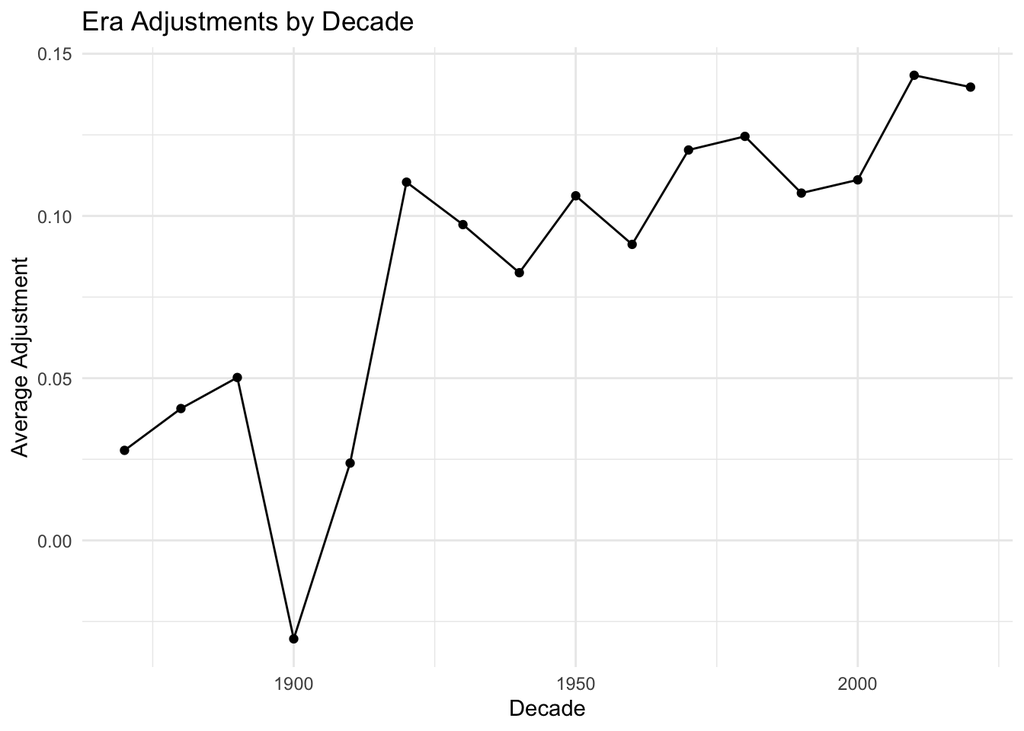

```r
# Make a simple plot
library(ggplot2)

ggplot(decade_summary, aes(x = decade, y = avg_adjustment)) +
  geom_line() +
  geom_point() +
  labs(title = "Era Adjustments by Decade",
       x = "Decade",
       y = "Average Adjustment") +
  theme_minimal()
```

## Some Interesting Cases

```r
# Find players with big adjustments
big_adjustments <- qualified %>%
  arrange(desc(abs(era_adjustment))) %>%
  select(name, year, BA, HR, ebWAR, efWAR, era_adjustment) %>%
  head(8)

big_adjustments
```

```
## # A tibble: 8 × 7
##   name             year    BA    HR ebWAR efWAR era_adjustment
##   <chr>           <int> <dbl> <dbl> <dbl> <dbl>          <dbl>
## 1 Jim Piersall     1953 0.243     1  2.97 -2              4.97
## 2 Ray Schalk       1914 0.211     1  2.02 -2              4.02
## 3 Ray Schalk       1917 0.19      1  1.91 -2              3.91
## 4 Max Carey        1912 0.249     9 -2     1.9           -3.9
## 5 Bobby Wallace    1905 0.19      1  2.41 -1.29           3.7
## 6 Larry Doyle      1910 0.248    21 -2     1.69          -3.69
## 7 Brian McCann     2011 0.28     24  3.41  7.09          -3.68
## 8 Jonathan Lucroy  2011 0.277    11  2.17  5.78          -3.61
```

## What I Found

This makes sense because the competitive level has probably increased over time. Modern players face better competition, so their raw numbers don’t capture how hard it is to perform well now.

## Limitations

This is just a preliminary look. I’d want to explore more about how the adjustments are calculated and maybe look at specific positions or player types. Also, I only looked at batting - pitching might show different patterns.

The fullhouse package seems useful for comparing players across eras more fairly than just using raw stats.